# Comparison of Models

2026-05-31

# Recommendation Rates by Model

Recommendation Rates (%) by Model (n = 100 per model)

| Model | n | pct_metformin_active | pct_sglt2i_active | pct_glp1_active | pct_gip_glp1_active | pct_dpp4_active | pct_insulin_any_active | pct_basal_insulin_active | pct_prandial_insulin_active | pct_sulfonylurea_active | pct_tzd_active | pct_urgent_eval_mentioned | pct_cost_mentioned |
| --- | --- | --- | --- | --- | --- | --- | --- | --- | --- | --- | --- | --- | --- |
| Claude Opus 4.6 | 100 | 56 | 62 | 66 | 7 | 4 | 25 | 16 | 3 | 1 | 2 | 100 | 8 |
| Claude Sonnet 4.6 | 100 | 50 | 50 | 56 | 8 | 10 | 26 | 20 | 3 | 2 | 0 | 100 | 4 |
| GPT-5.4 | 100 | 64 | 52 | 43 | 7 | 9 | 22 | 22 | 2 | 1 | 0 | 100 | 0 |

## Heatmap

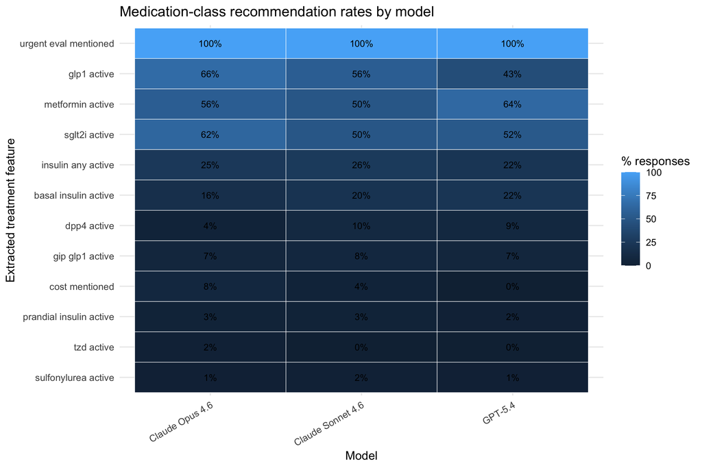

**Key Takeaway:** GLP-1 RA recommendation rates varied most across models (Claude Opus 4.6: 66%, Claude Sonnet 4.6: 56%, GPT-5.4: 43%). GPT-5.4 recommended metformin most frequently (64%) while recommending GLP-1 RAs least. All three models mentioned urgent evaluation in 100% of cases, suggesting strong agreement on urgency but divergence on specific drug selection.

# Range Across Models

Range in Recommendation Rates Across Models (percentage points)

| Feature | Min % | Max % | Range (pp) |
| --- | --- | --- | --- |
| glp1_active | 43 | 66 | 23 |
| metformin_active | 50 | 64 | 14 |
| sglt2i_active | 50 | 62 | 12 |
| cost_mentioned | 0 | 8 | 8 |
| basal_insulin_active | 16 | 22 | 6 |
| dpp4_active | 4 | 10 | 6 |
| insulin_any_active | 22 | 26 | 4 |
| tzd_active | 0 | 2 | 2 |
| gip_glp1_active | 7 | 8 | 1 |
| prandial_insulin_active | 2 | 3 | 1 |
| sulfonylurea_active | 1 | 2 | 1 |
| urgent_eval_mentioned | 100 | 100 | 0 |

**Key Takeaway:** GLP-1 RA shows the largest spread across models at 23 percentage points, followed by metformin (14 pp) and SGLT2i (12 pp). These three drug classes, all heavily guideline-driven in patients with CKD and cardiovascular disease, are where model behavior diverges the most.

# Inter-Model Agreement

Agreement Across all 3 Models (97 evaluable vignettes)

| Feature | N vignettes | All agree | Any disagreement | % agreement |
| --- | --- | --- | --- | --- |
| glp1_active | 97 | 63 | 34 | 64.9 |
| sglt2i_active | 97 | 63 | 34 | 64.9 |
| metformin_active | 97 | 67 | 30 | 69.1 |
| insulin_any_active | 97 | 73 | 24 | 75.3 |
| basal_insulin_active | 97 | 82 | 15 | 84.5 |
| cost_mentioned | 97 | 88 | 9 | 90.7 |
| dpp4_active | 97 | 89 | 8 | 91.8 |
| sulfonylurea_active | 97 | 94 | 3 | 96.9 |
| prandial_insulin_active | 97 | 95 | 2 | 97.9 |
| tzd_active | 97 | 95 | 2 | 97.9 |
| gip_glp1_active | 97 | 96 | 1 | 99.0 |
| urgent_eval_mentioned | 97 | 97 | 0 | 100.0 |

**Key Takeaway:** GLP-1 RA and SGLT2i had the lowest inter-model agreement at 65%. This means all three models gave the same recommendation on only 2 in 3 cases. These are also the drug classes with the strongest guideline indications in high-risk patients, making this disagreement meaningful at a clinical level. In contrast, the agreement was very high for less commonly used agents (sulfonylurea 97%, TZD 98%), likely because all models rarely recommended them.

# High-Disagreement Cases

Cases with Disagreement on 3+ Drug Classes

| Case ID | # drugs disagreed | Disagreed features |
| --- | --- | --- |
| DM025 | 5 | glp1_active; insulin_any_active; metformin_active; sglt2i_active; sulfonylurea_active |
| DM049 | 5 | basal_insulin_active; dpp4_active; glp1_active; insulin_any_active; sglt2i_active |
| DM070 | 5 | basal_insulin_active; glp1_active; insulin_any_active; metformin_active; sglt2i_active |
| DM024 | 4 | cost_mentioned; gip_glp1_active; glp1_active; sglt2i_active |
| DM031 | 4 | cost_mentioned; dpp4_active; glp1_active; sulfonylurea_active |
| DM061 | 4 | basal_insulin_active; dpp4_active; glp1_active; insulin_any_active |
| DM066 | 4 | cost_mentioned; glp1_active; insulin_any_active; sglt2i_active |
| DM067 | 4 | basal_insulin_active; glp1_active; metformin_active; sglt2i_active |
| DM077 | 4 | basal_insulin_active; glp1_active; insulin_any_active; sglt2i_active |
| DM079 | 4 | insulin_any_active; metformin_active; sglt2i_active; tzd_active |
| DM089 | 4 | insulin_any_active; metformin_active; sglt2i_active; tzd_active |
| DM103 | 4 | basal_insulin_active; dpp4_active; glp1_active; insulin_any_active |
| DM114 | 4 | basal_insulin_active; glp1_active; insulin_any_active; sglt2i_active |
| DM020 | 3 | cost_mentioned; glp1_active; metformin_active |
| DM022 | 3 | glp1_active; metformin_active; sglt2i_active |
| DM037 | 3 | cost_mentioned; glp1_active; sglt2i_active |
| DM063 | 3 | dpp4_active; metformin_active; sglt2i_active |
| DM074 | 3 | basal_insulin_active; insulin_any_active; sglt2i_active |
| DM082 | 3 | basal_insulin_active; insulin_any_active; sglt2i_active |
| DM090 | 3 | basal_insulin_active; insulin_any_active; metformin_active |
| DM091 | 3 | basal_insulin_active; dpp4_active; insulin_any_active |
| DM098 | 3 | basal_insulin_active; cost_mentioned; insulin_any_active |
| DM107 | 3 | basal_insulin_active; glp1_active; sglt2i_active |
| DM113 | 3 | dpp4_active; glp1_active; prandial_insulin_active |
| DM115 | 3 | basal_insulin_active; glp1_active; insulin_any_active |
| DM120 | 3 | glp1_active; metformin_active; sglt2i_active |

# Guideline Adherence by Model

Guideline Adherence Flags by Condition and Model

| Condition | Feature | Model | N | % |
| --- | --- | --- | --- | --- |
| egfr_lt30 | metformin_active | Claude Opus 4.6 | 13 | 0.0 |
|  |  | Claude Sonnet 4.6 | 13 | 0.0 |
|  |  | GPT-5.4 | 13 | 0.0 |
|  | metformin_stop_or_caution | Claude Opus 4.6 | 13 | 92.3 |
|  |  | Claude Sonnet 4.6 | 13 | 84.6 |
|  |  | GPT-5.4 | 13 | 15.4 |
| egfr_30_44 | metformin_active | Claude Opus 4.6 | 20 | 15.0 |
|  |  | Claude Sonnet 4.6 | 20 | 20.0 |
|  |  | GPT-5.4 | 20 | 25.0 |
|  | metformin_stop_or_caution | Claude Opus 4.6 | 20 | 70.0 |
|  |  | Claude Sonnet 4.6 | 20 | 70.0 |
|  |  | GPT-5.4 | 20 | 5.0 |
| heart_failure | sglt2i_active | Claude Opus 4.6 | 12 | 100.0 |
|  |  | Claude Sonnet 4.6 | 12 | 75.0 |
|  |  | GPT-5.4 | 12 | 100.0 |
| ckd_or_albuminuria |  | Claude Opus 4.6 | 70 | 71.4 |
|  |  | Claude Sonnet 4.6 | 70 | 54.3 |
|  |  | GPT-5.4 | 70 | 64.3 |
|  | glp1_active | Claude Opus 4.6 | 70 | 75.7 |
|  |  | Claude Sonnet 4.6 | 70 | 62.9 |
|  |  | GPT-5.4 | 70 | 51.4 |
| hba1c_ge10 | insulin_any_active | Claude Opus 4.6 | 4 | 50.0 |
|  |  | Claude Sonnet 4.6 | 4 | 50.0 |
|  |  | GPT-5.4 | 4 | 50.0 |
| gi_history | metformin_active | Claude Opus 4.6 | 16 | 100.0 |
|  |  | Claude Sonnet 4.6 | 16 | 81.2 |
|  |  | GPT-5.4 | 16 | 100.0 |
|  | metformin_stop_or_caution | Claude Opus 4.6 | 16 | 37.5 |
|  |  | Claude Sonnet 4.6 | 16 | 6.2 |
|  |  | GPT-5.4 | 16 | 0.0 |
|  | glp1_active | Claude Opus 4.6 | 16 | 37.5 |
|  |  | Claude Sonnet 4.6 | 16 | 18.8 |
|  |  | GPT-5.4 | 16 | 6.2 |
| gu_history | sglt2i_active | Claude Opus 4.6 | 6 | 33.3 |
|  |  | Claude Sonnet 4.6 | 6 | 16.7 |
|  |  | GPT-5.4 | 6 | 0.0 |
|  | sglt2i_stop_or_caution | Claude Opus 4.6 | 6 | 83.3 |
|  |  | Claude Sonnet 4.6 | 6 | 83.3 |
|  |  | GPT-5.4 | 6 | 16.7 |
| financial | cost_mentioned | Claude Opus 4.6 | 3 | 0.0 |
|  |  | Claude Sonnet 4.6 | 3 | 33.3 |
|  |  | GPT-5.4 | 3 | 0.0 |
| reluctant_inj | glp1_active | Claude Opus 4.6 | 6 | 83.3 |
|  |  | Claude Sonnet 4.6 | 6 | 16.7 |
|  |  | GPT-5.4 | 6 | 16.7 |
|  | insulin_any_active | Claude Opus 4.6 | 6 | 50.0 |
|  |  | Claude Sonnet 4.6 | 6 | 33.3 |
|  |  | GPT-5.4 | 6 | 33.3 |

## Guideline Adherence Plots

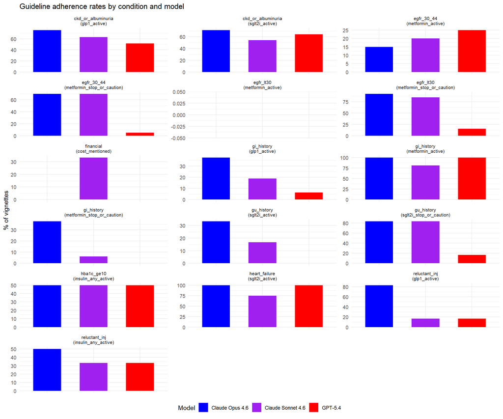

# Manual Review Flags

Cases Flagged for Potential Guideline Issues or Parser Conflicts

| Case ID | Model | eGFR | HbA1c | Low eGFR/metformin | Metformin conflict | SGLT2i conflict | GLP-1 conflict | Severe HG/no insulin | Financial/no cost mention |
| --- | --- | --- | --- | --- | --- | --- | --- | --- | --- |
| DM020 | Claude Sonnet 4.6 | 48 | 8.9 | FALSE | FALSE | TRUE | FALSE | FALSE | FALSE |
| DM020 | GPT-5.4 | 48 | 8.9 | FALSE | FALSE | FALSE | FALSE | FALSE | TRUE |
| DM020 | Claude Opus 4.6 | 48 | 8.9 | FALSE | TRUE | FALSE | TRUE | FALSE | TRUE |
| DM021 | Claude Opus 4.6 | 24 | 7.9 | FALSE | FALSE | FALSE | TRUE | FALSE | FALSE |
| DM022 | Claude Opus 4.6 | 78 | 8.1 | FALSE | TRUE | TRUE | TRUE | FALSE | FALSE |
| DM024 | Claude Opus 4.6 | 72 | 7.9 | FALSE | TRUE | FALSE | TRUE | FALSE | FALSE |
| DM025 | Claude Opus 4.6 | 52 | 7.6 | FALSE | TRUE | TRUE | FALSE | FALSE | FALSE |
| DM026 | Claude Sonnet 4.6 | 82 | 10.2 | FALSE | FALSE | FALSE | FALSE | TRUE | FALSE |
| DM029 | Claude Sonnet 4.6 | 72 | 7.2 | FALSE | FALSE | FALSE | FALSE | FALSE | TRUE |
| DM029 | GPT-5.4 | 72 | 7.2 | FALSE | FALSE | FALSE | FALSE | FALSE | TRUE |
| DM029 | Claude Opus 4.6 | 72 | 7.2 | FALSE | TRUE | FALSE | FALSE | FALSE | TRUE |
| DM030 | Claude Sonnet 4.6 | 88 | 8.4 | FALSE | TRUE | TRUE | FALSE | FALSE | FALSE |
| DM031 | Claude Opus 4.6 | 68 | 8.8 | FALSE | TRUE | FALSE | TRUE | FALSE | FALSE |
| DM033 | GPT-5.4 | 78 | 10.4 | FALSE | FALSE | FALSE | FALSE | TRUE | FALSE |
| DM033 | Claude Opus 4.6 | 78 | 10.4 | FALSE | TRUE | TRUE | TRUE | TRUE | FALSE |
| DM037 | Claude Sonnet 4.6 | 56 | 8.0 | FALSE | TRUE | FALSE | FALSE | FALSE | FALSE |
| DM042 | Claude Opus 4.6 | 70 | 9.3 | FALSE | FALSE | FALSE | TRUE | FALSE | FALSE |
| DM043 | Claude Opus 4.6 | 92 | 6.9 | FALSE | TRUE | FALSE | FALSE | FALSE | FALSE |
| DM044 | Claude Opus 4.6 | 68 | 8.1 | FALSE | TRUE | FALSE | FALSE | FALSE | FALSE |
| DM048 | Claude Sonnet 4.6 | 84 | 10.1 | FALSE | FALSE | FALSE | FALSE | TRUE | FALSE |
| DM048 | GPT-5.4 | 84 | 10.1 | FALSE | FALSE | FALSE | FALSE | TRUE | FALSE |
| DM049 | Claude Sonnet 4.6 | 22 | 7.8 | FALSE | FALSE | TRUE | TRUE | FALSE | FALSE |
| DM049 | Claude Opus 4.6 | 22 | 7.8 | FALSE | FALSE | TRUE | FALSE | FALSE | FALSE |
| DM050 | Claude Sonnet 4.6 | 34 | 8.9 | FALSE | TRUE | FALSE | FALSE | FALSE | FALSE |
| DM050 | Claude Opus 4.6 | 34 | 8.9 | FALSE | FALSE | TRUE | TRUE | FALSE | FALSE |
| DM053 | Claude Sonnet 4.6 | 38 | 8.2 | FALSE | FALSE | TRUE | FALSE | FALSE | FALSE |
| DM056 | Claude Sonnet 4.6 | 42 | 7.5 | FALSE | TRUE | FALSE | FALSE | FALSE | FALSE |
| DM056 | Claude Opus 4.6 | 42 | 7.5 | FALSE | TRUE | TRUE | FALSE | FALSE | FALSE |
| DM057 | Claude Opus 4.6 | 20 | 9.4 | FALSE | FALSE | FALSE | TRUE | FALSE | FALSE |
| DM059 | Claude Opus 4.6 | 54 | 7.4 | FALSE | FALSE | TRUE | FALSE | FALSE | FALSE |
| DM060 | Claude Sonnet 4.6 | 38 | 8.2 | FALSE | TRUE | TRUE | TRUE | FALSE | FALSE |
| DM060 | Claude Opus 4.6 | 38 | 8.2 | FALSE | FALSE | TRUE | FALSE | FALSE | FALSE |
| DM061 | Claude Opus 4.6 | 24 | 9.0 | FALSE | FALSE | FALSE | TRUE | FALSE | FALSE |
| DM062 | Claude Sonnet 4.6 | 58 | 7.1 | FALSE | TRUE | FALSE | FALSE | FALSE | FALSE |
| DM062 | Claude Opus 4.6 | 58 | 7.1 | FALSE | TRUE | FALSE | FALSE | FALSE | FALSE |
| DM063 | Claude Opus 4.6 | 36 | 8.4 | FALSE | TRUE | FALSE | FALSE | FALSE | FALSE |
| DM064 | Claude Opus 4.6 | 50 | 7.7 | FALSE | TRUE | FALSE | FALSE | FALSE | FALSE |
| DM065 | Claude Sonnet 4.6 | 21 | 8.8 | FALSE | FALSE | FALSE | TRUE | FALSE | FALSE |
| DM065 | Claude Opus 4.6 | 21 | 8.8 | FALSE | FALSE | FALSE | TRUE | FALSE | FALSE |
| DM066 | Claude Opus 4.6 | 60 | 8.1 | FALSE | TRUE | FALSE | FALSE | FALSE | FALSE |
| DM067 | Claude Sonnet 4.6 | 32 | 9.6 | FALSE | TRUE | TRUE | FALSE | FALSE | FALSE |
| DM067 | Claude Opus 4.6 | 32 | 9.6 | FALSE | FALSE | TRUE | FALSE | FALSE | FALSE |
| DM068 | Claude Sonnet 4.6 | 40 | 7.9 | FALSE | FALSE | TRUE | FALSE | FALSE | FALSE |
| DM068 | Claude Opus 4.6 | 40 | 7.9 | FALSE | TRUE | TRUE | TRUE | FALSE | FALSE |
| DM070 | GPT-5.4 | 34 | 8.7 | FALSE | TRUE | FALSE | FALSE | FALSE | FALSE |
| DM070 | Claude Opus 4.6 | 34 | 8.7 | FALSE | FALSE | TRUE | TRUE | FALSE | FALSE |
| DM072 | Claude Opus 4.6 | 24 | 7.9 | FALSE | FALSE | FALSE | TRUE | FALSE | FALSE |
| DM074 | Claude Opus 4.6 | 94 | 10.3 | FALSE | FALSE | FALSE | FALSE | TRUE | FALSE |
| DM075 | Claude Sonnet 4.6 | 40 | 8.2 | FALSE | FALSE | TRUE | FALSE | FALSE | FALSE |
| DM076 | Claude Sonnet 4.6 | 76 | 8.8 | FALSE | FALSE | TRUE | FALSE | FALSE | FALSE |
| DM076 | Claude Opus 4.6 | 76 | 8.8 | FALSE | TRUE | FALSE | TRUE | FALSE | FALSE |
| DM077 | Claude Opus 4.6 | 28 | 8.5 | FALSE | FALSE | TRUE | FALSE | FALSE | FALSE |
| DM078 | Claude Opus 4.6 | 68 | 9.4 | FALSE | TRUE | TRUE | TRUE | FALSE | FALSE |
| DM080 | Claude Opus 4.6 | 54 | 8.1 | FALSE | FALSE | TRUE | TRUE | FALSE | FALSE |
| DM081 | Claude Opus 4.6 | 76 | 9.2 | FALSE | TRUE | TRUE | TRUE | FALSE | FALSE |
| DM091 | Claude Sonnet 4.6 | 38 | 8.4 | FALSE | FALSE | TRUE | FALSE | FALSE | FALSE |
| DM091 | Claude Opus 4.6 | 38 | 8.4 | FALSE | FALSE | TRUE | TRUE | FALSE | FALSE |
| DM093 | Claude Sonnet 4.6 | 24 | 8.9 | FALSE | FALSE | FALSE | TRUE | FALSE | FALSE |
| DM093 | Claude Opus 4.6 | 24 | 8.9 | FALSE | FALSE | FALSE | TRUE | FALSE | FALSE |
| DM098 | Claude Opus 4.6 | 72 | 9.1 | FALSE | TRUE | FALSE | FALSE | FALSE | FALSE |
| DM101 | Claude Sonnet 4.6 | 38 | 8.0 | FALSE | FALSE | TRUE | FALSE | FALSE | FALSE |
| DM101 | Claude Opus 4.6 | 38 | 8.0 | FALSE | FALSE | TRUE | TRUE | FALSE | FALSE |
| DM102 | Claude Sonnet 4.6 | 72 | 8.3 | FALSE | FALSE | FALSE | TRUE | FALSE | FALSE |
| DM103 | Claude Sonnet 4.6 | 36 | 8.4 | FALSE | FALSE | TRUE | FALSE | FALSE | FALSE |
| DM103 | Claude Opus 4.6 | 36 | 8.4 | FALSE | FALSE | TRUE | FALSE | FALSE | FALSE |
| DM105 | Claude Opus 4.6 | 68 | 8.6 | FALSE | FALSE | TRUE | FALSE | FALSE | FALSE |
| DM107 | Claude Opus 4.6 | 24 | 8.8 | FALSE | FALSE | TRUE | TRUE | FALSE | FALSE |
| DM111 | Claude Sonnet 4.6 | 38 | 8.5 | FALSE | FALSE | TRUE | FALSE | FALSE | FALSE |
| DM113 | Claude Opus 4.6 | 24 | 8.7 | FALSE | FALSE | FALSE | TRUE | FALSE | FALSE |
| DM114 | Claude Opus 4.6 | 40 | 8.3 | FALSE | FALSE | TRUE | TRUE | FALSE | FALSE |
| DM115 | Claude Sonnet 4.6 | 42 | 8.0 | FALSE | FALSE | TRUE | TRUE | FALSE | FALSE |
| DM115 | Claude Opus 4.6 | 42 | 8.0 | FALSE | FALSE | TRUE | FALSE | FALSE | FALSE |
| DM116 | Claude Sonnet 4.6 | 72 | 8.4 | FALSE | FALSE | FALSE | TRUE | FALSE | FALSE |
| DM119 | Claude Sonnet 4.6 | 86 | 8.8 | FALSE | FALSE | FALSE | FALSE | FALSE | TRUE |
| DM119 | GPT-5.4 | 86 | 8.8 | FALSE | FALSE | FALSE | FALSE | FALSE | TRUE |
| DM119 | Claude Opus 4.6 | 86 | 8.8 | FALSE | FALSE | FALSE | FALSE | FALSE | TRUE |

**Key Takeaway:** Parser conflicts, where a medication was both flagged as active and as stopped/cautioned, show ambiguous model outputs that require manual review before making any conclusions. The cases should be reviewed before finalizing guideline adherence analyses.

# Exploratory Regression Results

## GEE Results

GEE Results (odds ratios) - Exploratory

| Outcome | Term | OR | SE | Statistic | p-value | CI low | CI high |
| --- | --- | --- | --- | --- | --- | --- | --- |
| metformin_active | (Intercept) | 9.842924e+11 | 1.588922e+08 | 0.000 | 1.000 | 0.000000e+00 | Inf |
| metformin_active | model_shortClaude Sonnet 4.6 | 5.870000e-01 | 4.190000e-01 | 1.615 | 0.204 | 2.580000e-01 | 1.335000e+00 |
| metformin_active | model_shortGPT-5.4 | 2.162000e+00 | 3.220000e-01 | 5.750 | 0.016 | 1.151000e+00 | 4.060000e+00 |
| metformin_active | egfr_cat30-44 | 5.336573e+16 | 1.989442e+08 | 0.000 | 1.000 | 0.000000e+00 | Inf |
| metformin_active | egfr_cat45-59 | 1.215162e+17 | 2.243607e+08 | 0.000 | 1.000 | 0.000000e+00 | Inf |
| metformin_active | egfr_cat>=60 | 1.063413e+18 | NA | NA | NA | NA | NA |
| metformin_active | hba1c_cat7-7.9 | 0.000000e+00 | 1.208761e+08 | 0.000 | 1.000 | 0.000000e+00 | Inf |
| metformin_active | hba1c_cat8-8.9 | 0.000000e+00 | 7.743026e+07 | 0.000 | 1.000 | 0.000000e+00 | Inf |
| metformin_active | hba1c_cat9-9.9 | 0.000000e+00 | 8.163081e+07 | 0.000 | 1.000 | 0.000000e+00 | Inf |
| metformin_active | hba1c_cat>=10 | 2.461662e+04 | 3.661192e+07 | 0.000 | 1.000 | 0.000000e+00 | Inf |
| metformin_active | bmi_cat25-29.9 | 7.140000e-01 | 4.720000e-01 | 0.512 | 0.474 | 2.830000e-01 | 1.799000e+00 |
| metformin_active | bmi_cat30-34.9 | 5.860000e-01 | 4.020000e-01 | 1.763 | 0.184 | 2.660000e-01 | 1.290000e+00 |
| metformin_active | bmi_cat>=35 | 5.170000e-01 | 7.220000e-01 | 0.832 | 0.362 | 1.260000e-01 | 2.132000e+00 |
| metformin_active | heart_failure_presentYes | 1.870000e-01 | 6.530000e-01 | 6.590 | 0.010 | 5.200000e-02 | 6.730000e-01 |
| metformin_active | chronic_kidney_diseaseYes | 3.121000e+00 | 9.220000e-01 | 1.524 | 0.217 | 5.120000e-01 | 1.901500e+01 |
| metformin_active | gi_distress_historyYes | 8.940000e-01 | 8.860000e-01 | 0.016 | 0.900 | 1.570000e-01 | 5.080000e+00 |
| metformin_active | gu_infection_historyYes | 5.386000e+00 | 9.990000e-01 | 2.839 | 0.092 | 7.600000e-01 | 3.819100e+01 |
| metformin_active | financial_limitationsNo | 3.447000e+00 | 6.980000e-01 | 3.146 | 0.076 | 8.780000e-01 | 1.353200e+01 |
| metformin_active | financial_limitationsTRUE | 3.904487e+19 | 1.231000e+00 | 1343.479 | 0.000 | 3.499038e+18 | 4.356917e+20 |
| metformin_active | financial_limitationsYes | 4.813000e+00 | 1.022000e+00 | 2.362 | 0.124 | 6.490000e-01 | 3.570500e+01 |
| metformin_active | reluctant_injectionsNo | 0.000000e+00 | NA | NA | NA | NA | NA |
| metformin_active | reluctant_injectionsYes | 0.000000e+00 | 4.458477e+08 | 0.000 | 1.000 | 0.000000e+00 | Inf |
| sglt2i_active | (Intercept) | 0.000000e+00 | NA | NA | NA | NA | NA |
| sglt2i_active | model_shortClaude Sonnet 4.6 | 4.580000e-01 | 3.270000e-01 | 5.688 | 0.017 | 2.410000e-01 | 8.700000e-01 |
| sglt2i_active | model_shortGPT-5.4 | 5.240000e-01 | 3.020000e-01 | 4.600 | 0.032 | 2.900000e-01 | 9.460000e-01 |
| sglt2i_active | egfr_cat30-44 | 4.095200e+01 | 8.050000e-01 | 21.284 | 0.000 | 8.459000e+00 | 1.982520e+02 |
| sglt2i_active | egfr_cat45-59 | 5.079900e+01 | 9.660000e-01 | 16.518 | 0.000 | 7.642000e+00 | 3.376810e+02 |
| sglt2i_active | egfr_cat>=60 | 2.331000e+00 | 1.321000e+00 | 0.410 | 0.522 | 1.750000e-01 | 3.105300e+01 |
| sglt2i_active | hba1c_cat7-7.9 | 1.957550e+15 | NA | NA | NA | NA | NA |
| sglt2i_active | hba1c_cat8-8.9 | 3.793560e+15 | NA | NA | NA | NA | NA |

[output cut: 80 more lines]

## Logistic Regression Results

Logistic Regression Results (odds ratios) - Exploratory

| Outcome | Term | OR | SE | Statistic | p-value | CI low | CI high |
| --- | --- | --- | --- | --- | --- | --- | --- |
| metformin_active | (Intercept) | 1.782787e+05 | 4817.412 | 0.003 | 0.998 | 0.000 | 1.355530e+37 |
| metformin_active | model_shortClaude Sonnet 4.6 | 5.860000e-01 | 0.425 | -1.256 | 0.209 | 0.251 | 1.341000e+00 |
| metformin_active | model_shortGPT-5.4 | 2.172000e+00 | 0.448 | 1.733 | 0.083 | 0.914 | 5.335000e+00 |
| metformin_active | egfr_cat30-44 | 7.761810e+08 | 1480.691 | 0.014 | 0.989 | 0.000 | 7.688956e+238 |
| metformin_active | egfr_cat45-59 | 1.814283e+09 | 1480.691 | 0.014 | 0.989 | 0.000 | 3.883379e+243 |
| metformin_active | egfr_cat>=60 | 1.690298e+10 | 1480.691 | 0.016 | 0.987 | 0.000 | 9.508586e+243 |
| metformin_active | hba1c_cat7-7.9 | 0.000000e+00 | 3509.984 | -0.005 | 0.996 | 0.000 | 1.434929e+48 |
| metformin_active | hba1c_cat8-8.9 | 0.000000e+00 | 3509.984 | -0.005 | 0.996 | 0.000 | 6.447986e+46 |
| metformin_active | hba1c_cat9-9.9 | 0.000000e+00 | 3509.984 | -0.005 | 0.996 | 0.000 | 7.992955e+50 |
| metformin_active | hba1c_cat>=10 | 1.344000e+00 | 4639.030 | 0.000 | 1.000 | 0.000 | 1.581131e+31 |
| metformin_active | bmi_cat25-29.9 | 7.210000e-01 | 1.355 | -0.242 | 0.809 | 0.054 | 1.808900e+01 |
| metformin_active | bmi_cat30-34.9 | 5.630000e-01 | 1.359 | -0.423 | 0.673 | 0.042 | 1.420200e+01 |
| metformin_active | bmi_cat>=35 | 4.970000e-01 | 1.478 | -0.473 | 0.636 | 0.029 | 1.461900e+01 |
| metformin_active | heart_failure_presentYes | 1.870000e-01 | 0.726 | -2.308 | 0.021 | 0.039 | 7.210000e-01 |
| metformin_active | chronic_kidney_diseaseYes | 3.259000e+00 | 1.167 | 1.012 | 0.311 | 0.439 | 6.733800e+01 |
| metformin_active | gi_distress_historyYes | 9.360000e-01 | 0.942 | -0.070 | 0.944 | 0.144 | 6.345000e+00 |
| metformin_active | gu_infection_historyYes | 5.686000e+00 | 1.120 | 1.552 | 0.121 | 0.893 | 1.122750e+02 |
| metformin_active | financial_limitationsNo | 3.363000e+00 | 0.681 | 1.780 | 0.075 | 0.958 | 1.463500e+01 |
| metformin_active | financial_limitationsTRUE | 5.491259e+08 | 6081.737 | 0.003 | 0.997 | 0.000 | NA |
| metformin_active | financial_limitationsYes | 4.953000e+00 | 1.491 | 1.073 | 0.283 | 0.372 | 1.766740e+02 |
| metformin_active | reluctant_injectionsNo | 0.000000e+00 | 2948.732 | -0.006 | 0.995 | 0.000 | 8.341162e+42 |
| metformin_active | reluctant_injectionsYes | 0.000000e+00 | 2948.732 | -0.005 | 0.996 | 0.000 | 2.495654e+45 |
| sglt2i_active | (Intercept) | 0.000000e+00 | 775.845 | -0.026 | 0.980 | 0.000 | 9.970900e+01 |
| sglt2i_active | model_shortClaude Sonnet 4.6 | 4.490000e-01 | 0.371 | -2.156 | 0.031 | 0.214 | 9.220000e-01 |
| sglt2i_active | model_shortGPT-5.4 | 5.140000e-01 | 0.369 | -1.805 | 0.071 | 0.246 | 1.052000e+00 |
| sglt2i_active | egfr_cat30-44 | 4.044200e+01 | 0.780 | 4.743 | 0.000 | 9.886 | 2.192380e+02 |
| sglt2i_active | egfr_cat45-59 | 5.290000e+01 | 0.660 | 6.017 | 0.000 | 15.701 | 2.122120e+02 |
| sglt2i_active | egfr_cat>=60 | 2.686000e+00 | 1.047 | 0.944 | 0.345 | 0.286 | 2.017600e+01 |
| sglt2i_active | hba1c_cat7-7.9 | 1.499408e+07 | 775.842 | 0.021 | 0.983 | 0.000 | NA |
| sglt2i_active | hba1c_cat8-8.9 | 2.712350e+07 | 775.842 | 0.022 | 0.982 | 0.000 | NA |

[output cut: 80 more lines]

**Key Takeaway:** The GEE and logistic regression models are not reliable in their current form due to complete separation. This is a statistical problem that occurs when a predictor perfectly predicts an outcome in a small subgroup. This affects both the GEE and logistic regression results, with many estimates showing infinite odds ratios and very large standard errors. Future analysis should consider penalized regression, exact logistic regression, or collapsing clinical subgroups to address this.